# Why are Employees Leaving

#### 3. Analysis for Employee type - `Bad Fit`.

1. Distribution of Average monthly hours.

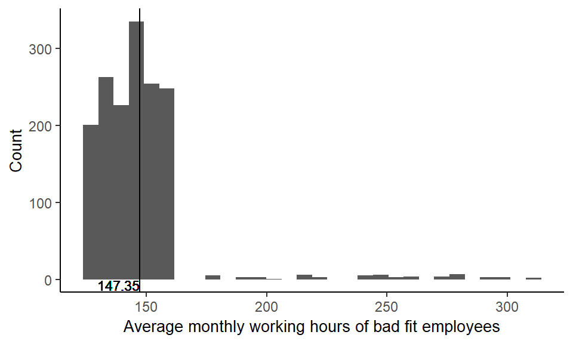

Figure: How many hours do bad fit people work?

2. Promotions in last five years

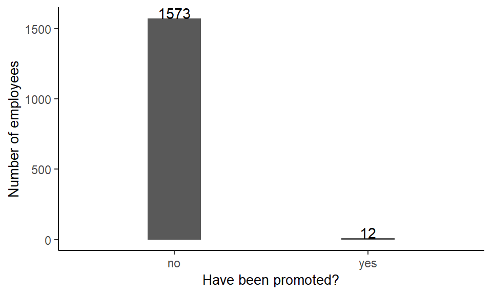

Figure: How many bad fit people at work get promoted?

3. Pay grade

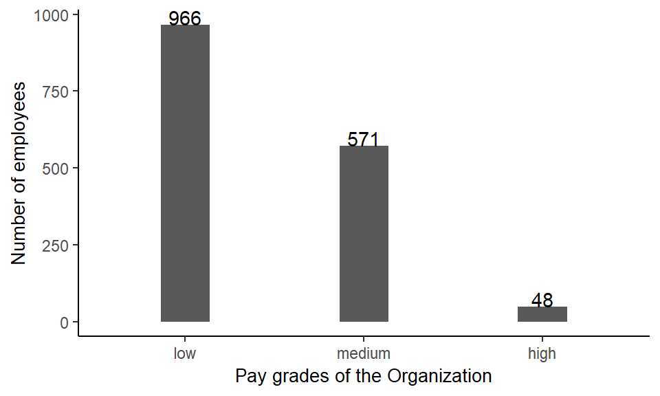

Figure: To which pay grade do bad fit people belong?

4. Work accidents

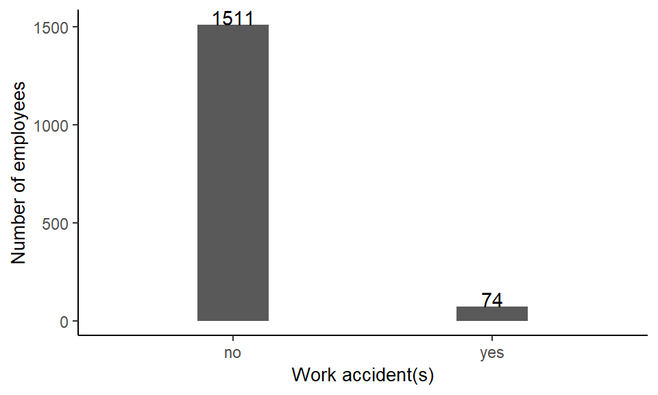

Figure: How many work accident were bad fit people involved in?

5. Number of projects that were worked on.

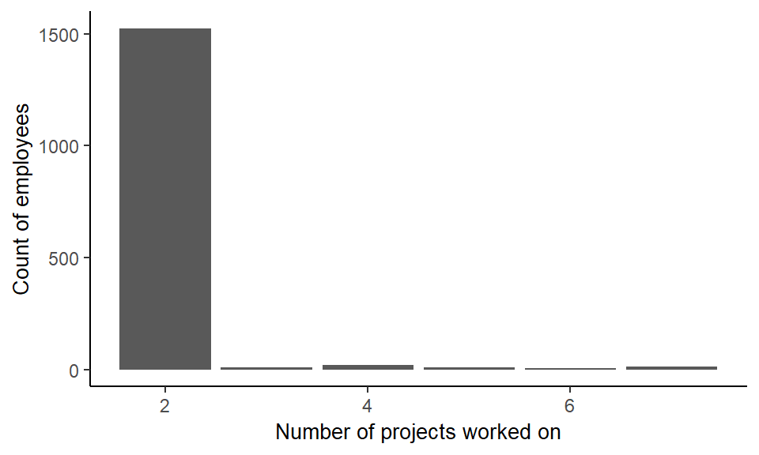

6. Tenure of employment

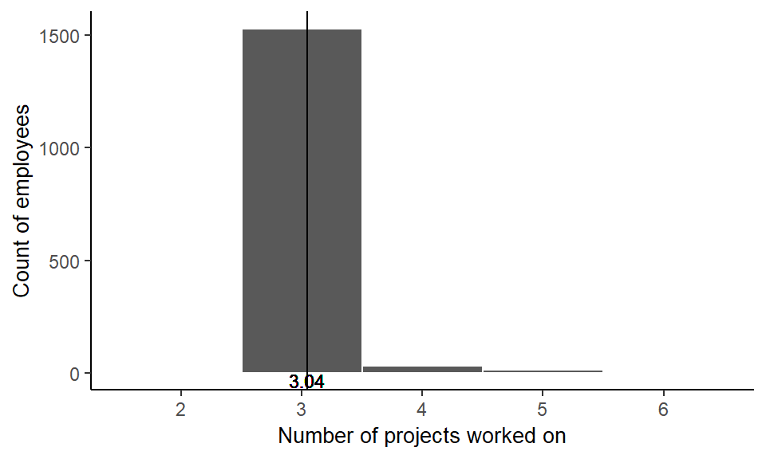

# Final plots and Summary

#### Plot 1: Distribution of Average mothly working hours for each employee type.

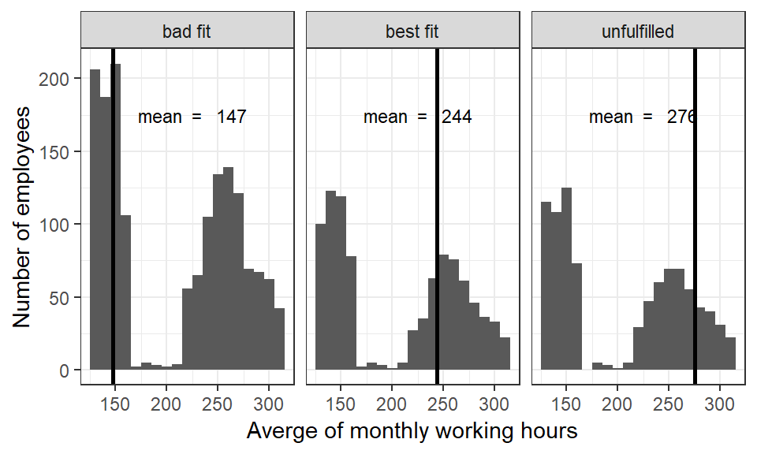

Figure: Plot 1: Distribution of Average mothly working hours by employee type

- As we are aware the time logged in each employee is in the order of bad fit < best fit < unfulfilled.

#### Plot 2: Pay grade of each employee type.

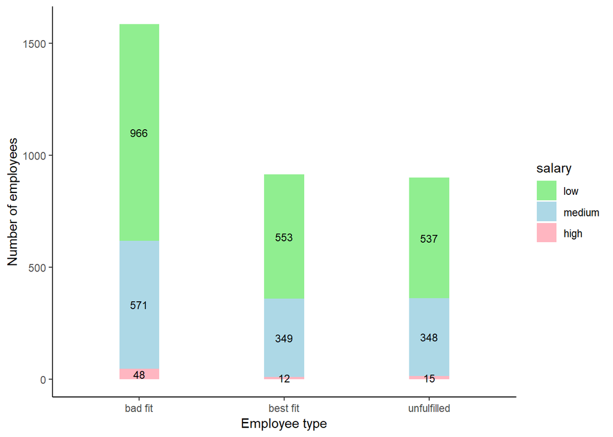

Figure: Pay grade in the organization

- A major chunk of employees belong to same pay grade - `low`, and the order of their appearence is unfulfilled < best fit < bad fit.

#### Plot 3: Average number of projects worked on by each of the employee type.

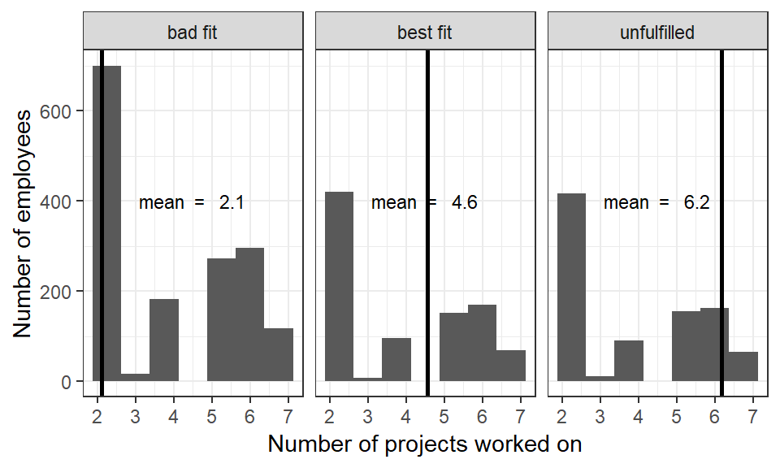

- We can see that, bad fit people are rarely engaged on projects, but the organization depends on the best fit and unfulfilled people to handle major chunk of projects.

# Reflections

- After digging this deep, I can conclude the following,
  1. If there is no **work-life balance**: i.e., if employees are **`too engaged`** or if they are **`not too engaged`**, people *leave*.
  2. If there are no promotions at right time, employees *leave*.
  3. `Pay grade` is the major factor that has caused about `25%` of employment churn in this orgainization.
  4. On an average `4.5%` of the total employees leave because of work accidents.
- The main challenge while performing EDA on this dataset was, I was concluding based on aboslute numbers rather than on percentages, which lead to wrong interpretations and conclusions on the dataset.
- Another challegne that I had faced was the tidiness of the dataset, it is so clean and and the quality of the data, which made the process of finding patterns and insights very difficult.
- Further course of action on this dataset, would be to build predictor models for percentage employment churn; i.e., using the machine learning models/techniques to build and predict what are the causes for employment churn, based on the variables available.
- Another set of action, that can be done, is to use the Hypotheses Testing methods to find the correlations between two categorical variables.